# Bài ôn tập buổi 5&6: Canxi

#### Một sinh viên học khoa dinh dưỡng muốn xem xét mối quan hệ giữa lượng canxi (calcium_intake g/day) và kiến thức về canxi knowledge_score (thang đo 0 đến 5) ở các sinh viên trong lớp học. Và cô ấy muốn biết liệu kiến thức về canxi có thể được sử dụng để dự đoán lượng canxi của sinh viên hay không. Cô ấy đã thu thập dữ liệu và lưu trong tập tin canxi.xlsx.

### Hãy thực hiện các yêu cầu được liệt kê sau đây:

1. Đọc dữ liệu. Xem thông tin dữ liệu với head(), tail(), str(), summary().
2. Vẽ biểu đồ phân phối tần suất của knowledge_score. Nhận xét.
3. Thực hiện các thống kê cơ bản cho knowledge_score và calcium_intake (mean, median, mode, max, min, range)
4. Cho biết các giá trị ở phân vị thứ 20, 35, 65 và 90 của calcium_intake. Biểu diễn phân vị và giá trị tương ứng trên biểu đồ.
5. Vẽ boxplot cho knowledge_score và cho calcium_intake. knowledge_score có outlier hay không? calcium_intake có outlier hay không? Nếu có thì hãy thay thế outlier này bằng giá trị phù hợp. Giá trị bạn chọn để thay thế là giá trị nào (mean/median/…)? Giải thích.
6. Tìm phương sai (variance) của knowledge_score và calcium_intake.
7. Tìm độ lệch chuẩn (Standard deviation) của knowledge_score và calcium_intake.
8. Tìm độ xiên (Skewness) và độ nhọn (Kurtosis) của knowledge_score. Nhận xét kết quả.
9. Vẽ biểu đồ thể hiện mối quan hệ giữa knowledge_score và calcium_intake. Nhận xét.
10. Tính giá trị covariance, correlation giữa knowledge_score và calcium_intake.

```r
library("xlsx")
library("ggplot2")
library("ggExtra")
library("tidyverse")
library("mlbench")
library("e1071")
```

#### 1. Đọc dữ liệu. Xem thông tin dữ liệu với head(), tail(), str(), summary().

```r
data <- read.xlsx("canxi.xlsx", sheetName = "Sheet1")
head(data)
tail(data)
```

| response_number | knowledge_score | calcium_intake |
| --- | --- | --- |
| 1 | 1.0 | 0.450 |
| 2 | 4.2 | 1.050 |
| 3 | 3.8 | 0.900 |
| 4 | 1.5 | 0.525 |
| 5 | 2.2 | 0.710 |
| 6 | 3.2 | 0.854 |

|  | response_number | knowledge_score | calcium_intake |
| --- | --- | --- | --- |
| 15 | 15 | 2.2 | 0.583 |
| 16 | 16 | 4.5 | 0.850 |
| 17 | 17 | 1.8 | 0.798 |
| 18 | 18 | 2.4 | 0.754 |
| 19 | 19 | 3.0 | 0.805 |
| 20 | 20 | 4.3 | 1.085 |

```r
print(summary(data))
```

```
 response_number knowledge_score calcium_intake
 Min.   : 1.00   Min.   :1.00    Min.   :0.4500
 1st Qu.: 5.75   1st Qu.:2.20    1st Qu.:0.7250
 Median :10.50   Median :2.90    Median :0.7990
 Mean   :10.50   Mean   :2.96    Mean   :0.7851
 3rd Qu.:15.25   3rd Qu.:3.85    3rd Qu.:0.8955
 Max.   :20.00   Max.   :4.80    Max.   :1.0850
```

```r
str(data)
```

```
'data.frame':	20 obs. of  3 variables:
 $ response_number: num  1 2 3 4 5 6 7 8 9 10 ...
 $ knowledge_score: num  1 4.2 3.8 1.5 2.2 3.2 4 1.4 2.6 3.2 ...
 $ calcium_intake : num  0.45 1.05 0.9 0.525 0.71 0.854 0.8 0.493 0.73 0.894 ...
```

#### 2. Vẽ biểu đồ phân phối tần suất của knowledge_score. Nhận xét.

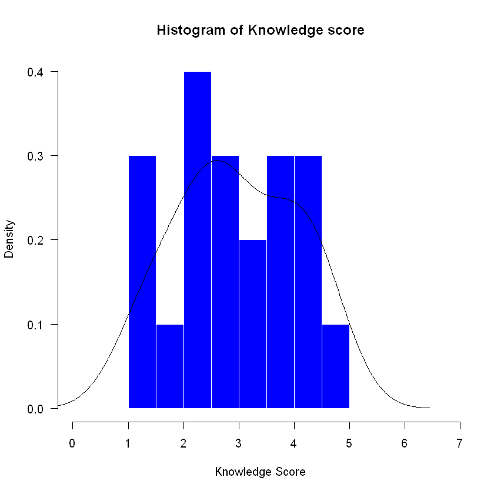

```r
# Cach 1
hist(data$knowledge_score, xlab = "Knowledge Score", main = "Histogram of Knowledge score",
                     xlim = c(0, max(data$knowledge_score) + 2),freq = FALSE, col = "blue", las = 1, border = FALSE)
lines(density(data$knowledge_score))
```

```r
# Cach 2
plot <- ggplot(data, aes(knowledge_score, lw=2))  +
geom_histogram(aes(y=..density..),bins =5, color="white", fill="blue") +
geom_density(col="red") +
ggtitle('Histogram of Knowledge score') +
theme_bw(base_size = 12)
```

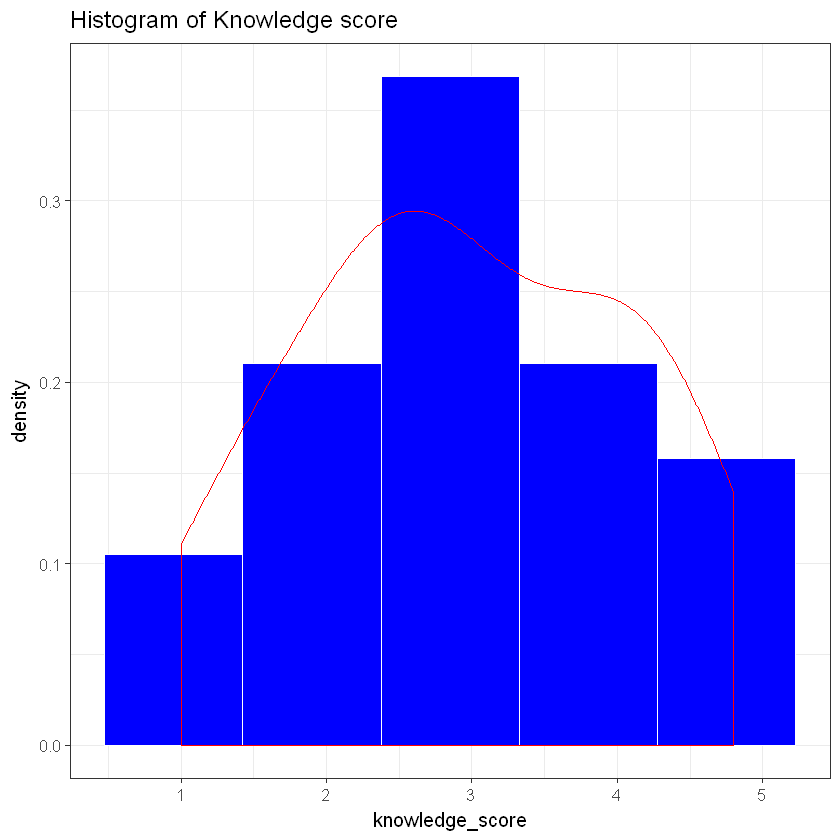

```r
plot
```

**Nhận xét:**

- HV tự nhận xét

#### 3. Thực hiện các thống kê cơ bản cho knowledge_score và calcium_intake (mean, median, mode, max, min, range)

```r
# Create the function.
getmode <- function(v) {
   uniqv <- unique(v)
   uniqv[which.max(tabulate(match(v, uniqv)))]
}
```

```r
#knowledge_score
print("Thong ke chung cua knowledge_score:")
print(summary(data$knowledge_score))
range_ks = (max(data$knowledge_score) - min(data$knowledge_score))

print(paste(" Mode of knowledge_score:", toString(getmode(data$knowledge_score))))
print(paste(" Range of knowledge_score:", range_ks))
```

```
[1] "Thong ke chung cua knowledge_score:"
   Min. 1st Qu.  Median    Mean 3rd Qu.    Max.
   1.00    2.20    2.90    2.96    3.85    4.80
[1] " Mode of knowledge_score: 3.8"
[1] " Range of knowledge_score: 3.8"
```

```r
#calcium_intake
print("Thong ke chung cua calcium_intake:")
print(summary(data$calcium_intake))
range_ci = max(data$calcium_intake) - min(data$calcium_intake)
print(paste(" Mode of calcium_intake:", toString(getmode(data$calcium_intake))))
print(paste(" Range of calcium_intake:", range_ci))
```

```
[1] "Thong ke chung cua calcium_intake:"
   Min. 1st Qu.  Median    Mean 3rd Qu.    Max.
 0.4500  0.7250  0.7990  0.7851  0.8955  1.0850
[1] " Mode of calcium_intake: 0.45"
[1] " Range of calcium_intake: 0.635"
```

#### 4. Cho biết các giá trị ở phân vị thứ 20, 35, 65 và 90 của calcium_intake. Biểu diễn phân vị và giá trị tương ứng trên biểu đồ.

```r
calcium_quantitle = quantile(data$calcium_intake, c(0.2, 0.35, 0.65, 0.9))
calcium_quantitle
```

**20%**

0.6846

**35%**

0.74665

**65%**

0.8514

**90%**

0.9915

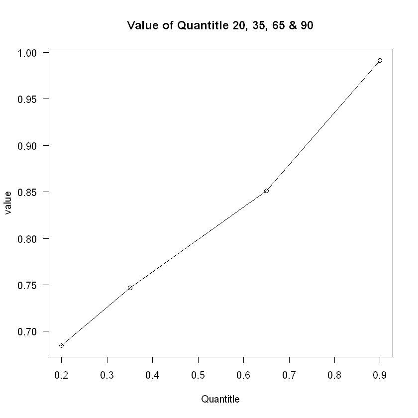

```r
#plot the line
plot(c(0.2, 0.35, 0.65, 0.9), calcium_quantitle, xlab = "Quantitle", ylab = "value",
     main = "Value of Quantitle 20, 35, 65 & 90", type = "o", las = 1)
```

#### 5. Vẽ boxplot cho knowledge_score và cho calcium_intake. knowledge_score có outlier hay không? calcium_intake có outlier hay không? Nếu có thì hãy thay thế outlier này bằng giá trị phù hợp. Giá trị bạn chọn để thay thế là giá trị nào (mean/median/…)? Giải thích.

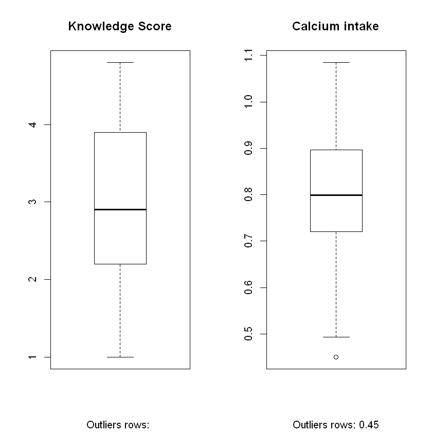

```r
par(mfrow = c(1,2))
boxplot(data$knowledge_score, main = "Knowledge Score",
        sub = paste("Outliers rows:", boxplot.stats(data$knowledge_score)$out))
boxplot(data$calcium_intake, main = "Calcium intake",
        sub = paste("Outliers rows:", boxplot.stats(data$calcium_intake)$out))
```

**Nhận xét:**

- Knowledge Score không có outlier.
- Calcium intake có outliers dưới -> Sẽ cập nhật lại giá trị của outliers này bằng giá trị median, do giá trị median không bị tác động bởi những outliers so với giá trị min, max và mean.

```r
# Cap nhat lai gia tri outliers cho Calcium intake
calcium_outliers <- boxplot.stats(data$calcium_intake)$out
print(paste("Numrows of outliers: ", sum(data$calcium_intake == calcium_outliers[1])))
```

```
[1] "Numrows of outliers:  1"
```

```r
# Cap nhat gia tri outlier cua Calcium intake thanh median cua calcium intake
data$calcium_intake[data$calcium_intake == calcium_outliers] <- median(data$calcium_intake)
```

```r
summary(data)
```

```
 response_number knowledge_score calcium_intake
 Min.   : 1.00   Min.   :1.00    Min.   :0.4930
 1st Qu.: 5.75   1st Qu.:2.20    1st Qu.:0.7322
 Median :10.50   Median :2.90    Median :0.7995
 Mean   :10.50   Mean   :2.96    Mean   :0.8025
 3rd Qu.:15.25   3rd Qu.:3.85    3rd Qu.:0.8955
 Max.   :20.00   Max.   :4.80    Max.   :1.0850
```

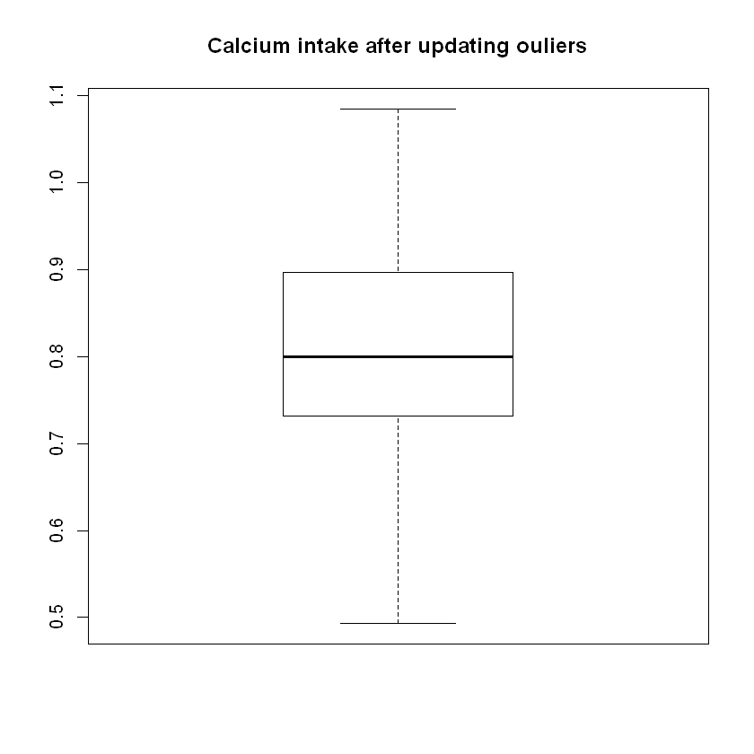

```r
boxplot(data$calcium_intake, main = "Calcium intake after updating ouliers")
```

#### 6. Tìm phương sai (variance) của knowledge_score và calcium_intake.

```r
# Cach 1
var <- sapply(data[,2:3],var)
var
```

**knowledge_score**

1.22568421052632

**calcium_intake**

0.0241915236842105

```r
# Cach 2
var(data$calcium_intake)
```

0.0241915236842105

```r
var(data$knowledge_score)
```

1.22568421052632

#### 7. Tìm độ lệch chuẩn (Standard deviation) của knowledge_score và calcium_intake

```r
# Cach 1
sd <- sapply(data[,2:3],sd)
sd
```

**knowledge_score**

1.10710623271948

**calcium_intake**

0.155536245564211

```r
# Cach 2
sd(data$calcium_intake)
```

0.155536245564211

```r
sd(data$knowledge_score)
```

1.10710623271948

#### 8. Tìm độ xiên (Skewness) và độ nhọn (Kurtosis) của knowledge_score. Nhận xét kết quả.

```r
print(paste("skweness of knowledge_score:",skewness(data$knowledge_score)))
print(paste("kurtosis of knowledge_score:",kurtosis(data$knowledge_score)))
```

```
[1] "skweness of knowledge_score: -0.0246196905430348"
[1] "kurtosis of knowledge_score: -1.24569607239671"
```

**Nhận xét:**

- Skewness < 0: phân phối lệch trái
- Kurtosis < 3: phân phối thấp hơn phân phối chuẩn

#### 9. Vẽ biểu đồ thể hiện mối quan hệ giữa knowledge_score và calcium_intake có bổ sung thêm histogram phụ trên mỗi cột. Nhận xét biểu đồ.

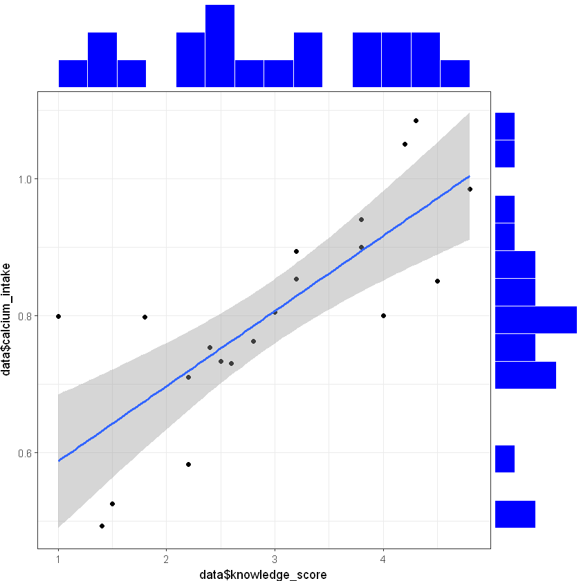

```r
plot <- ggplot(data = data, aes(x= data$knowledge_score, y= data$calcium_intake))
plot <- plot + geom_point() +
         geom_smooth(method="lm") +
         theme_bw()
ggMarginal(plot, type = "histogram", fill="blue", bins = 15, col = "white")
```

**Nhận xét:**

- HV tự nhận xét

#### 10. Tính giá trị covariance, correlation giữa knowledge_score và calcium_intake.

```r
#Covariane
print(paste("Covariancce giua knowledge_score và calcium_intake: ", cov(data$knowledge_score,data$calcium_intake)))
```

```
[1] "Covariancce giua knowledge_score và calcium_intake:  0.134333684210526"
```

```r
#Correlation
print(paste("Covariancce giua knowledge_score và calcium_intake: ", cor(data$knowledge_score,data$calcium_intake)))
```

```
[1] "Covariancce giua knowledge_score và calcium_intake:  0.780124682060638"
```